# Project 4: Wrangle Report

## 1 Brief Introduction

In this project, the goal is wrangle **WeRateDogs Twitter** data to create interesting and trustworthy analyses and visualizations. The Twitter archive data available in csv format is only contains very basic tweet information. Thus, I need to gather additional data, then assessing and cleaning it before analysing and come out with visalizations.

## 2 Objective

This document is to briefly describes my wrangling efforts in this project.

## 3 Data Wrangling

### 3.1 Gather

The data collected from three sources:

1. **WeRateDogs** Twitter archive, `twitter_archive_enhanced.csv`, which can be downloaded manually from the link given by Udacity.
2. The tweet image predictions, i.e. what breed of dog is present in each tweet. Data store in `image_predictions.tsv` and is hosted on Udacity's servers. I downloaded it programmatically using the `Requests` library.
3. Additional tweet's data, for example the `retweet count` and `favorite` ("like") count, using the `tweet ID` in the **WeRateDogs** Twitter archive, query the Twitter API for each tweet's JSON data using Python's **Tweepy** library and store each tweet's entire set of JSON data in a file, named `tweet_json.txt`.

Prior to query Twitter's API, steps I need to do are:

```
- Sign up for a Twitter account
- Set up a developer account, follow the directions on Twitter's Developer Portal.
- Once my developer account is approved, I can generate the consumer API keys, the Access Token and Access Token Secret that I need to create an API object that I can use to gather Twitter data.
```

### 3.2 Assess

After gathering each of the above pieces of data, I assess them visually and programmatically for quality and tidiness issues.

#### 3.2.1 Quality issues:

This refers to data with content's problem, such as missing data, inaccurate data, inconsistent data, incorrect data type.

- Quality issues observed are incorrect data type for example the date data in string format instead of datetime, tweet_id in integer format instead of string format.
- Inaccurate data detected for `rating_numerator` and `rating_denominator`. Some of the ratings with decimal values were incorrectly extracted. Inaccurate data also detected in `name` column, some of them are not dog's name

#### 3.2.2 Tidiness issues

This refers to messy datas with structural problem. Tidy data should have the following characteristics:

- Each variable forms a column
- Each observation forms a row
- Each type of observational unit forms a table.

Some examples of issues observed in the dataset:

- `dog stages` should be a single column instead of four, which violate the requirement of each variable forms a column.
- All the 3 datasets refer to same observational unit, that is everything related to tweet's post. Thus, these 3 datasets should be merged into 1 as they are part of the same observation unit (tweets).

### 3.3 Clean

Each data quality and data tidiness issues detected in assessing step were cleaned. Each item was defined, coded and tested to ensure the issue is addressed correctly.

#### 3.3.1 Quality issues:

An example of the **data quality** issue is the incorrect data in rating related column. Some of the rating with decimal values are incorrectly extracted. The current pipeline captures incorrect values when rating numerators contact decimals. As such, I clean it by extracting the ratings again from the `text` column from the `twitter_archive` table. This is done by using the regex to extract the rating with either:

```
13/10 (without decimal)
or
9.75/10.0 (with decimal)
```

and group them by the `/` seperator into `numerator` and `denominal`.

A [useful tool](https://regex101.com/) recommended by my reviewer is a great tool for me to find the correct regex to do the above task. The regex that I used showed below:

```
ratings = twitter_clean.text.str.extract('(\d+\.?\d+|\d+)\/(\d+\.?\d+|\d+)',
                               expand=True)
```

#### 3.3.2 Tidiness issues

An example of the **data tidiness** issue is the dog stages should be a single column rather than four (`doggo`,`floofer`,`pupper`,`puppo`), as showed below

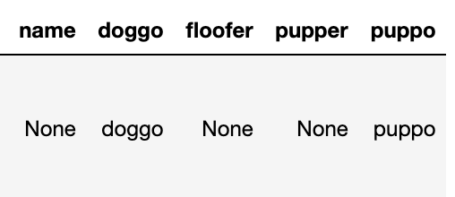

```python
from IPython.display import Image
Image(filename='./photo/dog_stages.png')
```

I replace all *None* value in these 4 columns with empty string "". Then I combine all the value in these 4 columns, row by row. There are some rows found to have **two** dog stages, example doggo & puppo. I manually verify the data by refering to the `text` column. Once validated, I convert the empty string to *None* again. Last but not least, I drop the 4 unwanted columns (`doggo`,`floofer`,`pupper`,`puppo`)

```
#create new column to list the dog stage by row
twitter_clean['dog_stage'] = twitter_clean[['doggo', 'floofer', 'pupper', 'puppo']].replace('None','').sum(1)


# drop unwanted column: `doggo`,`floofer`,`pupper`,`puppo`
twitter_clean.drop(columns = ['doggo', 'floofer', 'pupper', 'puppo'], inplace = True)
```